# Manuscript

Erwin Kers

01-09-2022

Important! set working directory to where you saved the data/ R script

```r
#working directory
setwd("C:/Users/Erwin/OneDrive/Manuscript Erwin Kers/R script + data/Manuscript-1.0")

#change time to english for correct labels
Sys.setlocale("LC_TIME", "English")
```

```
[1] "English_United States.1252"
```

```r
#libraries for all following plots
library(oce)
library(lubridate)
library(reshape2)
library(MBA)
library(mgcv)
library(plyr)
library(tidyverse)
library(dplyr)
library(cowplot)
library(readxl)
library(ggthemes)
```

## CTD plots

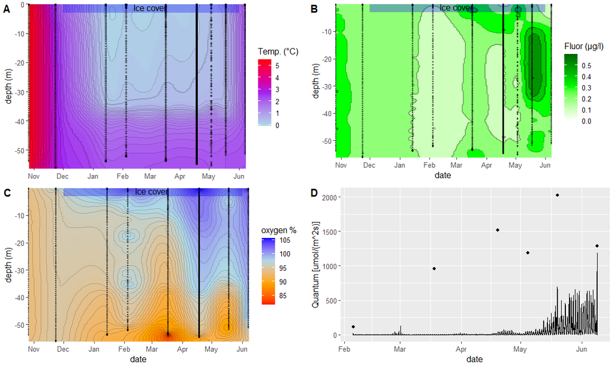

## Environmental observations

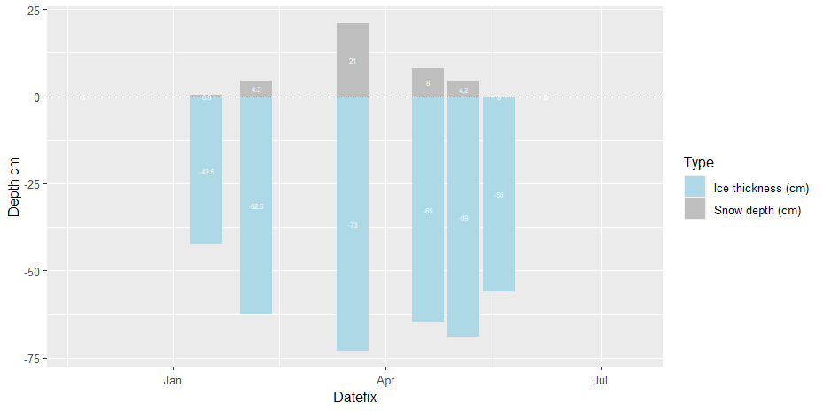

## light sensor data (might not include in paper?)

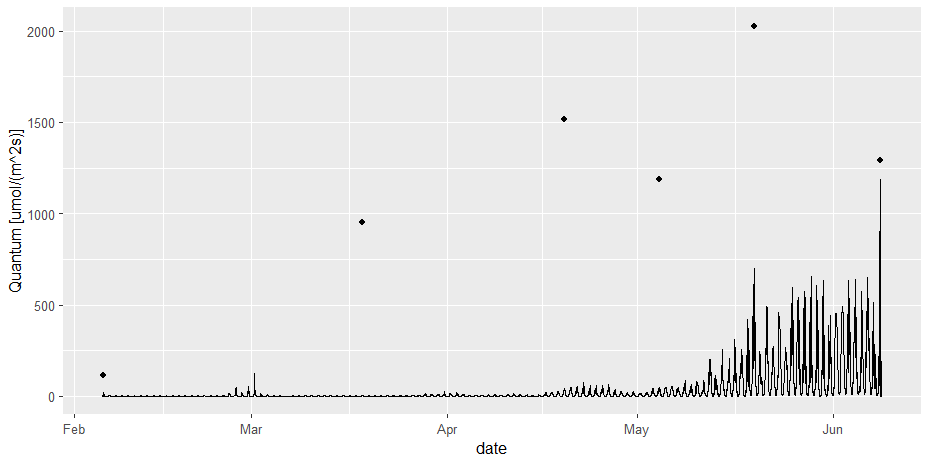

## Nutrient data

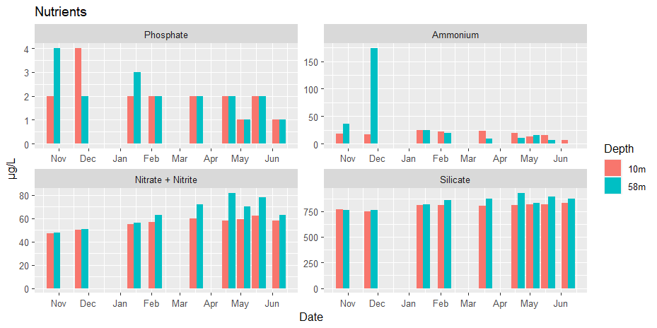

## Chlorophyll A data

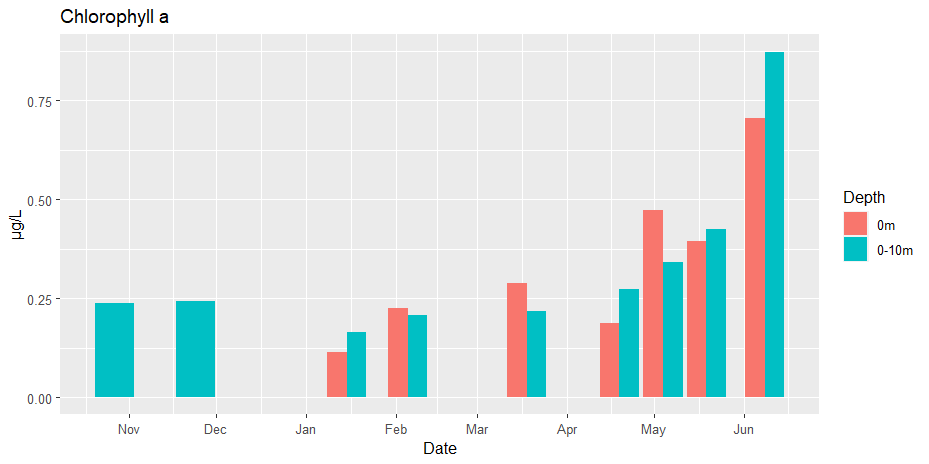

## Phytoplankton community

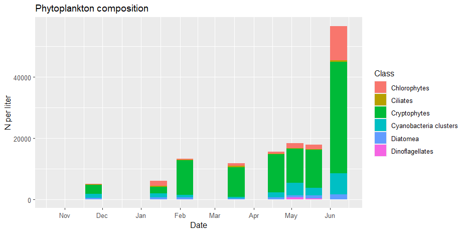

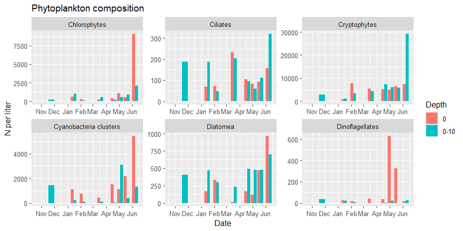

## Rotifer composition

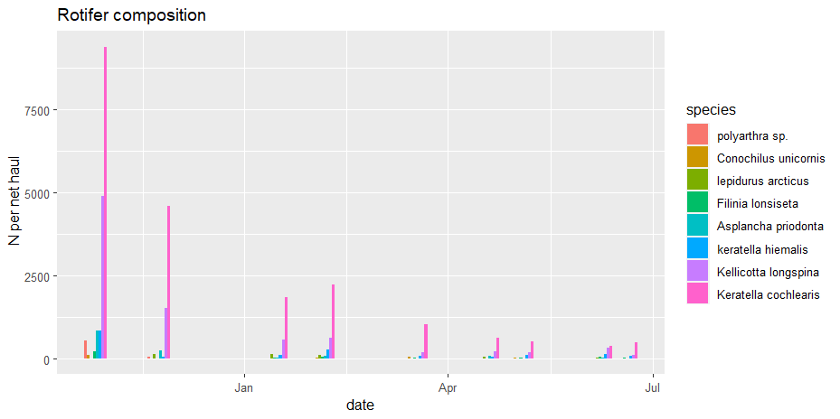

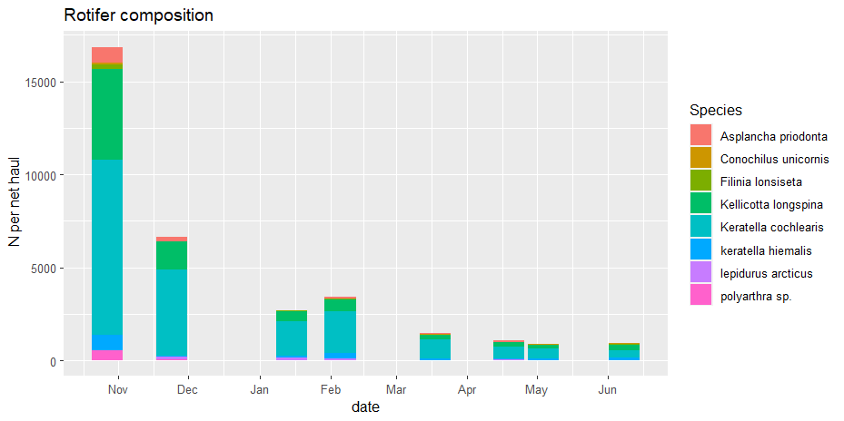

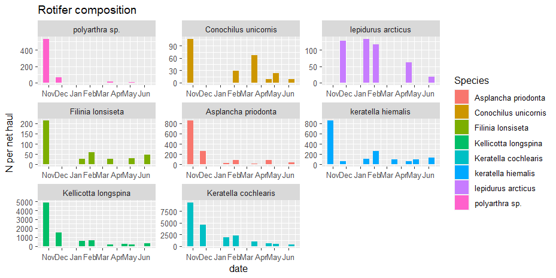

## Zooplankton Biomass

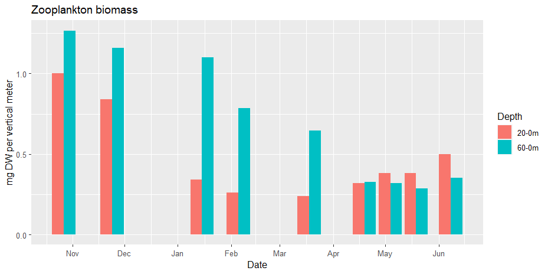

## !!! combined plot !!!!!

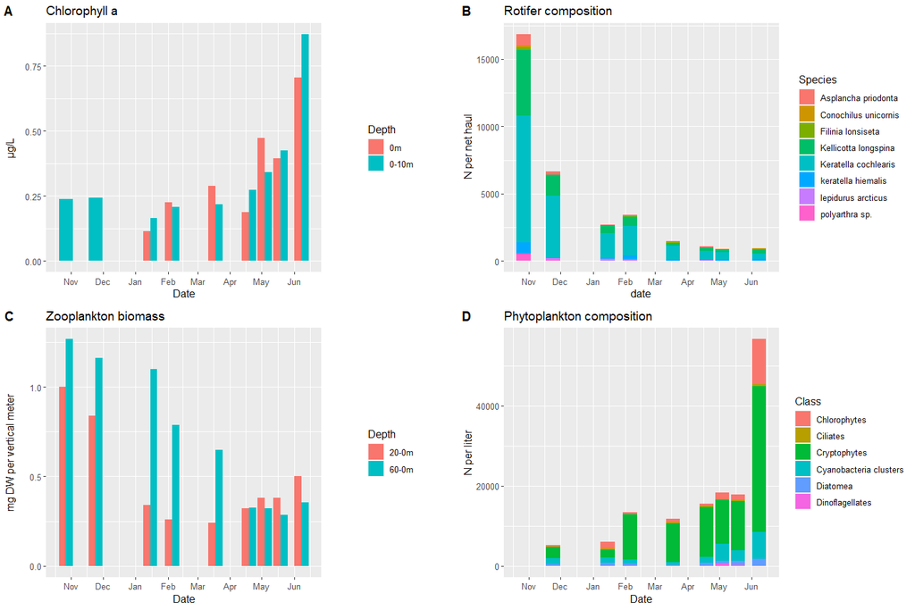

## Zooplankton community

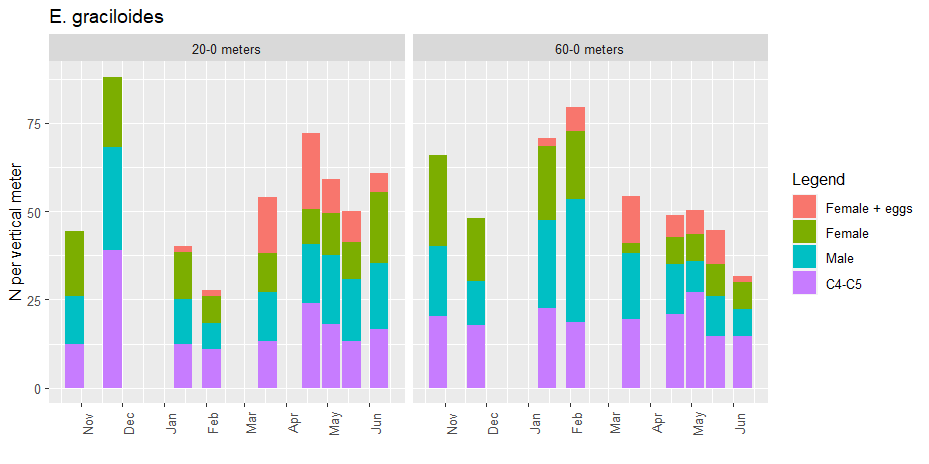

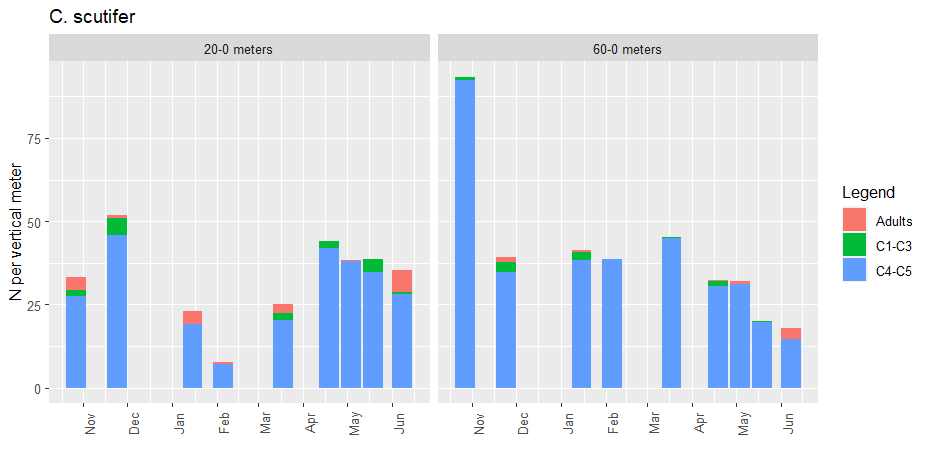

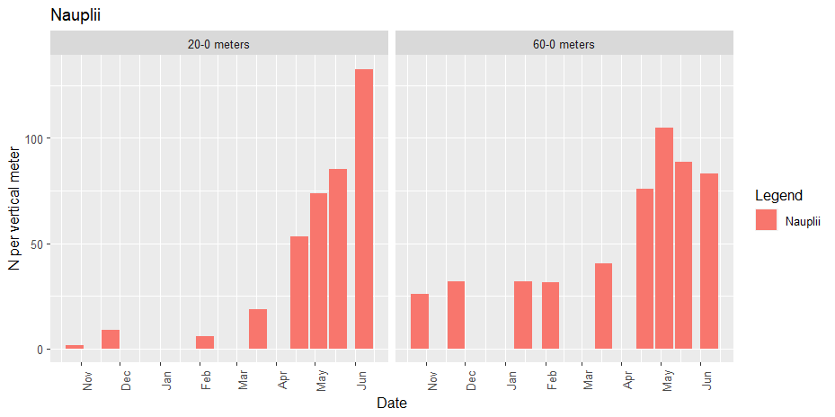

### Combined zooplankton community

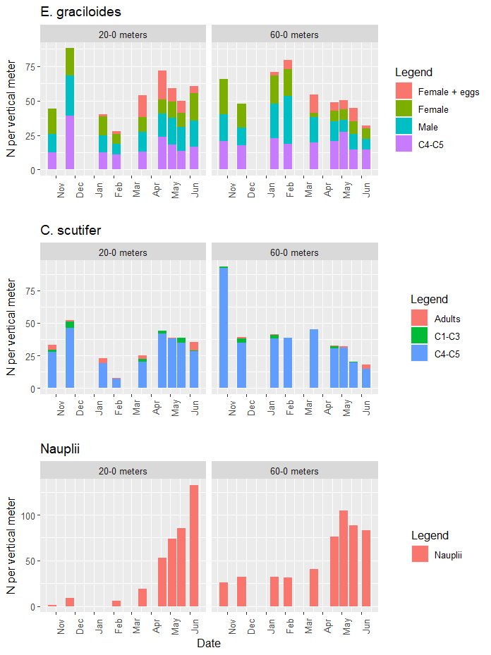

## Total lipids over time

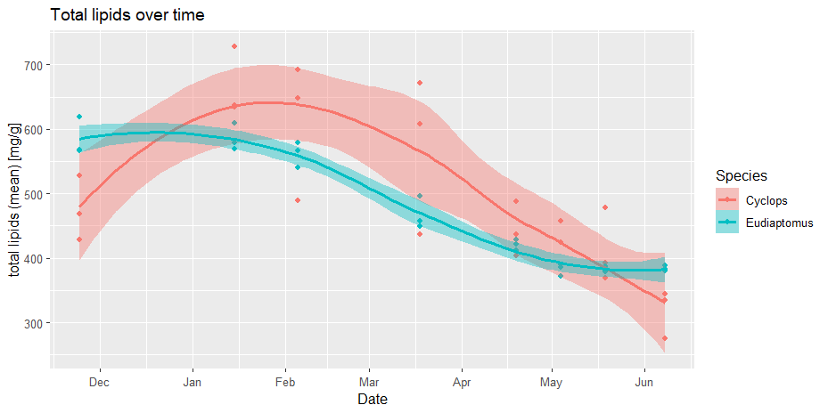

There is a large difference between the previous and next plot, in the Total lipids plot it seems Cyclops has an higher lipid content. When looking at the FA classes if you’d add them up Eudiaptomus has higher content of FAME. This makes me wonder is it normal to have such a difference between to two species in glycerol content? Is this purely due to the difference in storage and membrane lipds?

(or is there something beside the removal of glycerol that can cause this difference?)

## FA groups over time

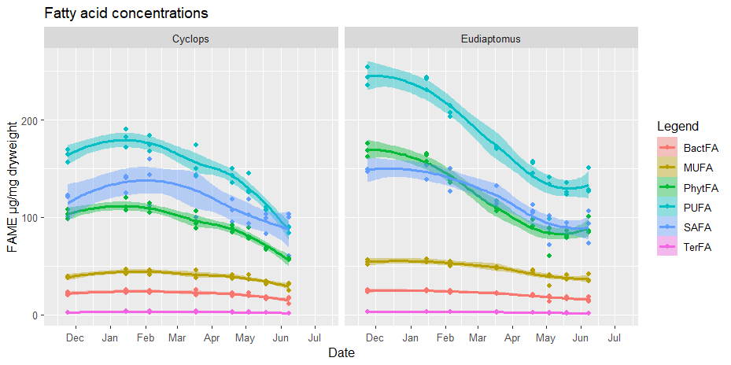

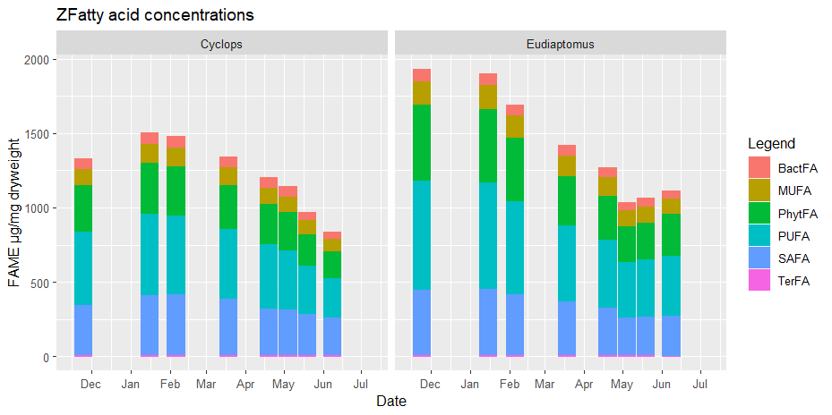

## FA per L of POM

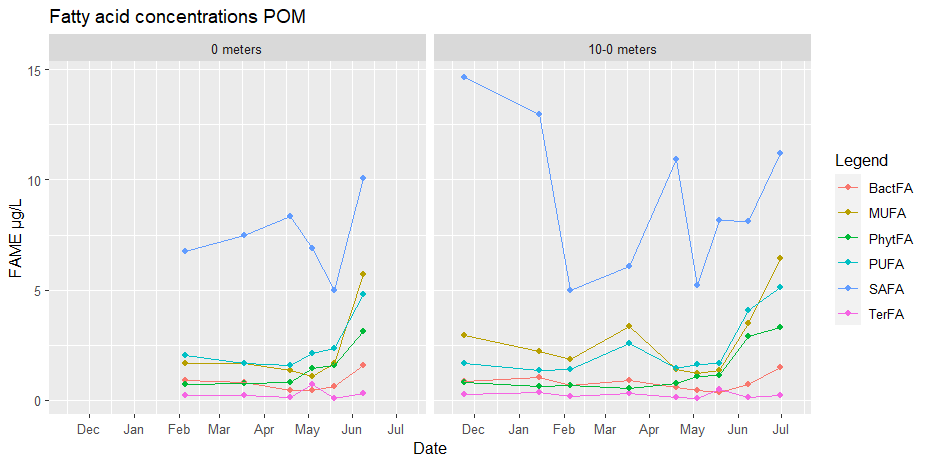

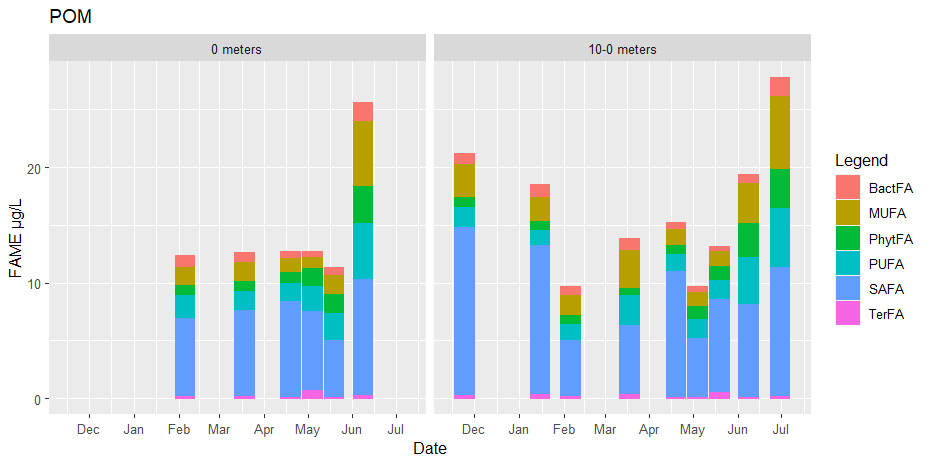

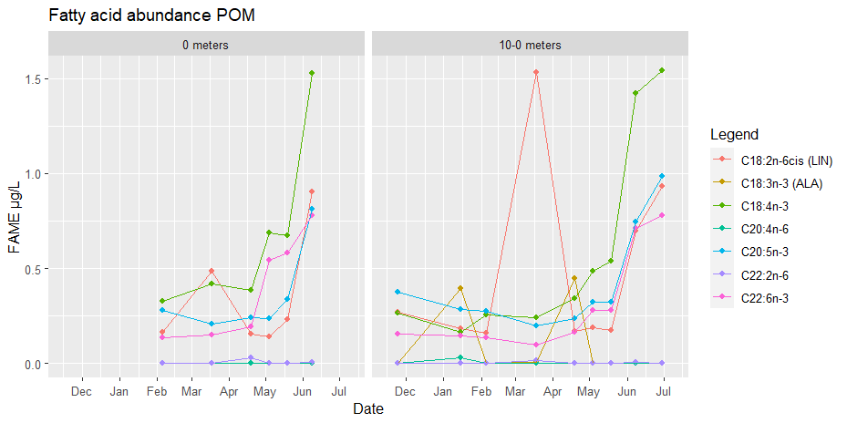

## Difference between total lipids and total FAME

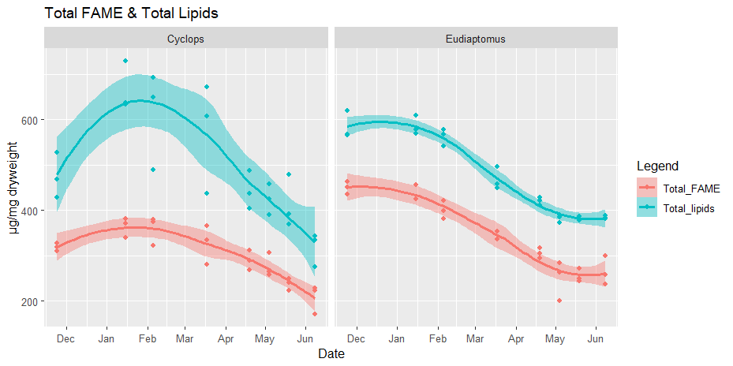

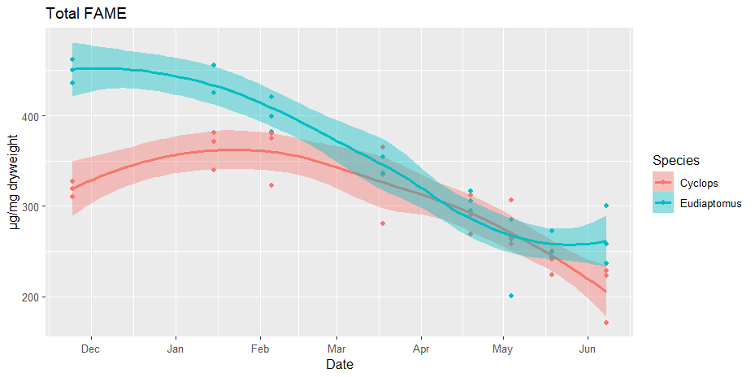

## FAME % per grouped FA

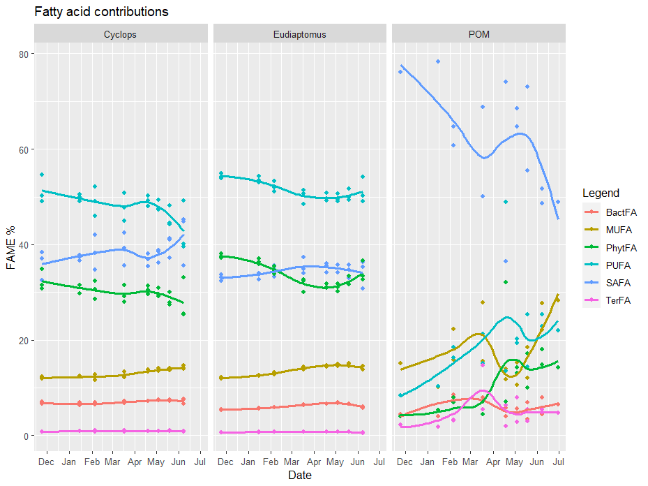

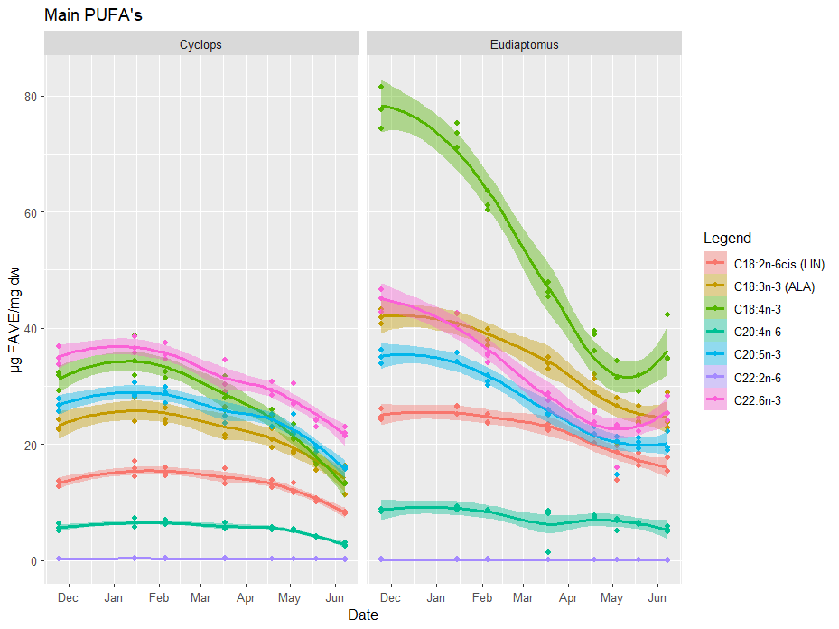

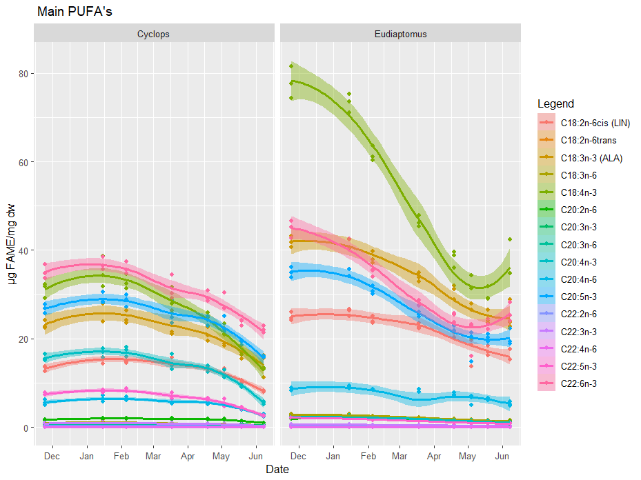

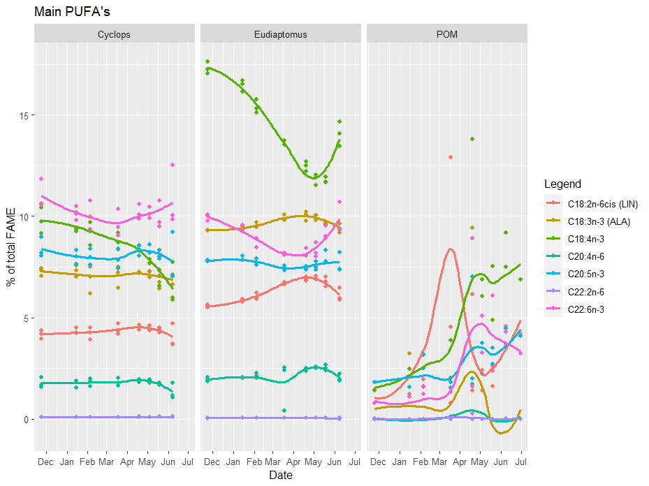

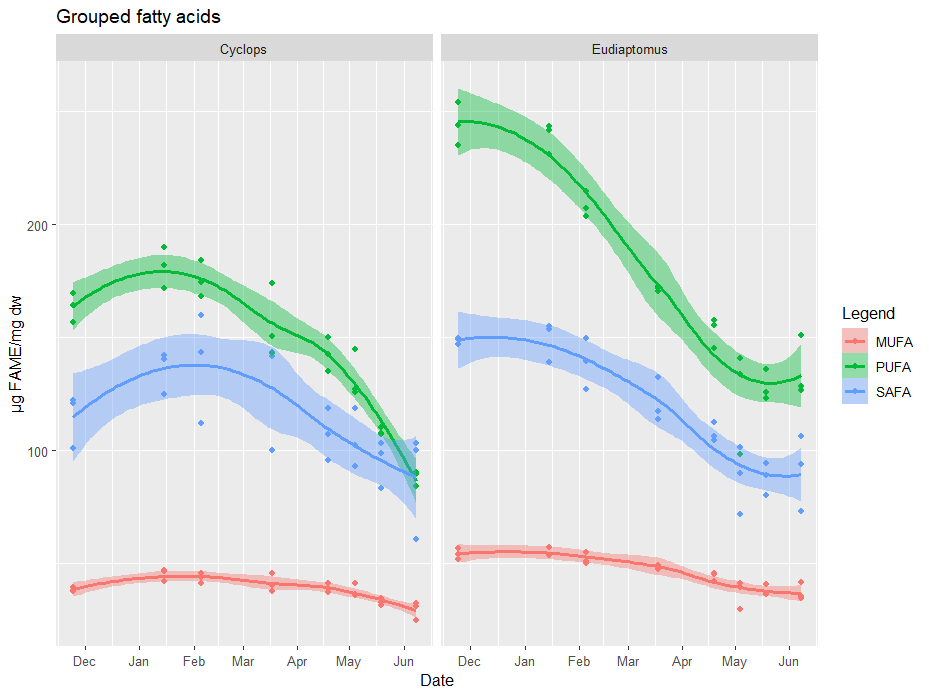

# added plot 2

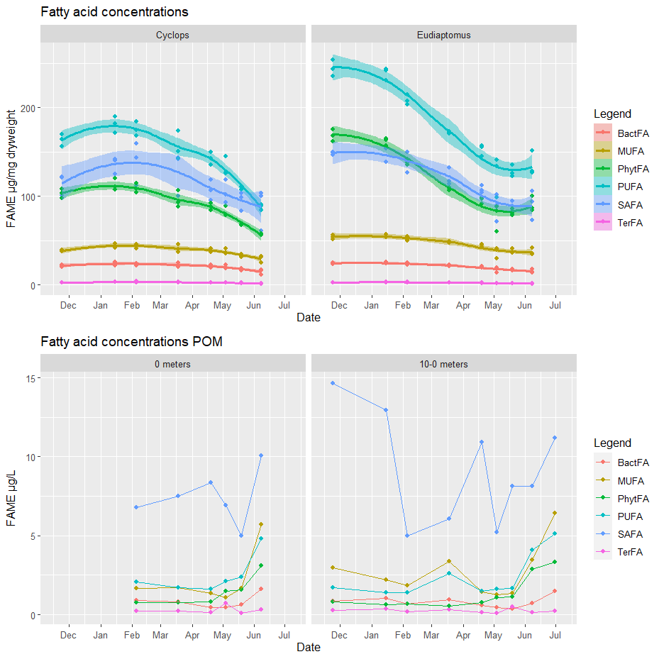

# CA plots

## CA ALL (to appendix)

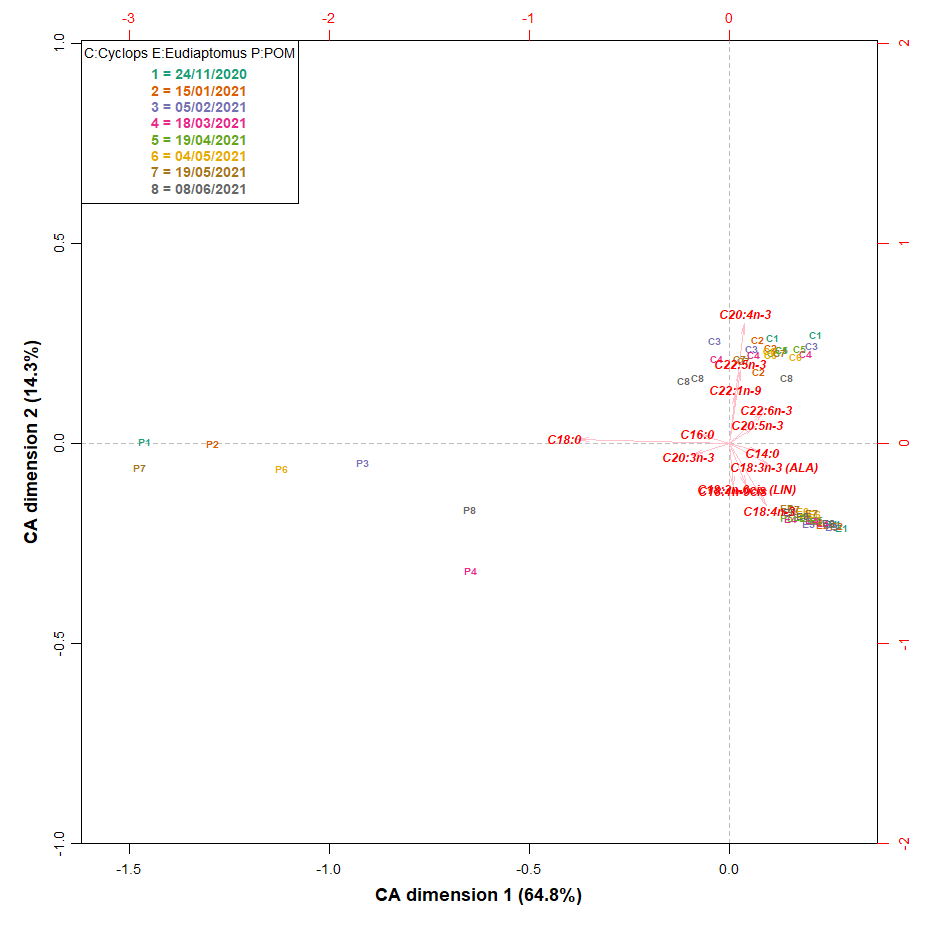

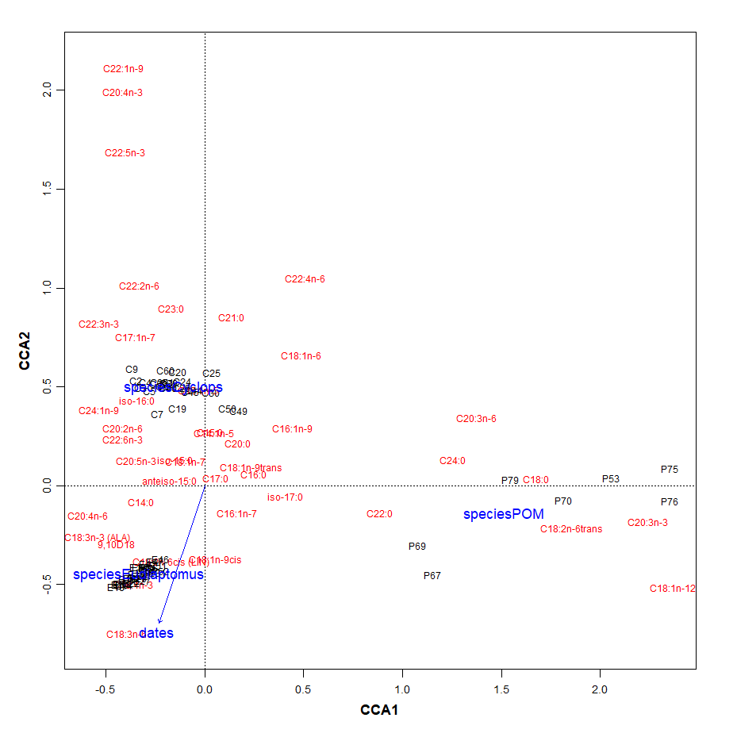